# Final STAT 341 Report

Author

Celia Carey, Noelle Haviland, Heewon Yi

## Read in dataset

```r
library(readxl)
exchange <- read_excel("fredgraph.xlsx")
glimpse(exchange)
```

```
Rows: 1,350
Columns: 5
$ observation_date                           <dttm> 2020-02-03, 2020-02-04, 20…
$ `DFF (Federal Funds rate)`                 <dbl> 1.59, 1.59, 1.59, 1.59, 1.5…
$ `BRARECDM (Brazilian recession indicator)` <dbl> 1, 1, 1, 1, 1, 1, 1, 1, 1, …
$ `IHLIDXUS (Job Posting)`                   <dbl> 100.03, 100.06, 100.13, 100…
$ `DEXBZUS (exchange rate)`                  <dbl> 4.2411, 4.2405, 4.2567, 4.2…
```

Variable Standardization

```r
exchange <- exchange |>
  rename(FedFundsRate = "DFF (Federal Funds rate)",
         RecessionIndicator = "BRARECDM (Brazilian recession indicator)",
         JobPostings = "IHLIDXUS (Job Posting)",
         Reals_USD_Exchange = "DEXBZUS (exchange rate)") |>
  mutate(FedFundsRate_scaled = as.numeric(scale(FedFundsRate)),
         JobPostings_scaled = as.numeric(scale(JobPostings)),
         RecessionIndicator = as.numeric(if_else(RecessionIndicator == "0", 1, 2)))

exchange <- exchange |>
  drop_na(Reals_USD_Exchange)
```

```r
exchange <- exchange |>
  select(FedFundsRate_scaled, JobPostings_scaled, Reals_USD_Exchange, RecessionIndicator)
```

```r
# Compose data for stan model
stan_exchange <- compose_data(exchange)
```

## Research Question

To what degree does the US’s Fed have on the Brazilian Reals to USD EXR based on their control over the Federal Funds Rate?

## Where is the data from?

The data is from the FRED website and we’re looking at how the Brazilian Reals to USD Spot Exchange Rate (https://fred.stlouisfed.org/series/DEXBZUS#, Data Updated: 2025-04-07) is affected by the:

- US Federal Funds Effective Rate, Percent, Daily, Not Seasonally Adjusted (https://fred.stlouisfed.org/series/DFF#, Data Updated: 2025-04-07)
- OECD based Recession Indicators for Brazil from the Peak through the Trough, +1 or 0, Daily, Not Seasonally Adjusted (https://fred.stlouisfed.org/series/BRARECDM#, Data Updated: 2022-11-10)
- Job Postings on Indeed in the United States, Index Feb, 1 2020=100, Daily, Seasonally Adjusted (https://fred.stlouisfed.org/series/IHLIDXUS#, Data Updated: 2025-04-08)

We first acquired data on April 3, but ultimately changed our minds and downloaded data on April 8 that we are planning to use. The data comes from the FRED website and is identified by an alphacode title (DEXBZUS, DFF,BRARECDM, and IHLIDXUS).

To format it in excel after downloading, we lined up the daily data that came in two sheets and placed the columns next to one another.

## Causal Diagram

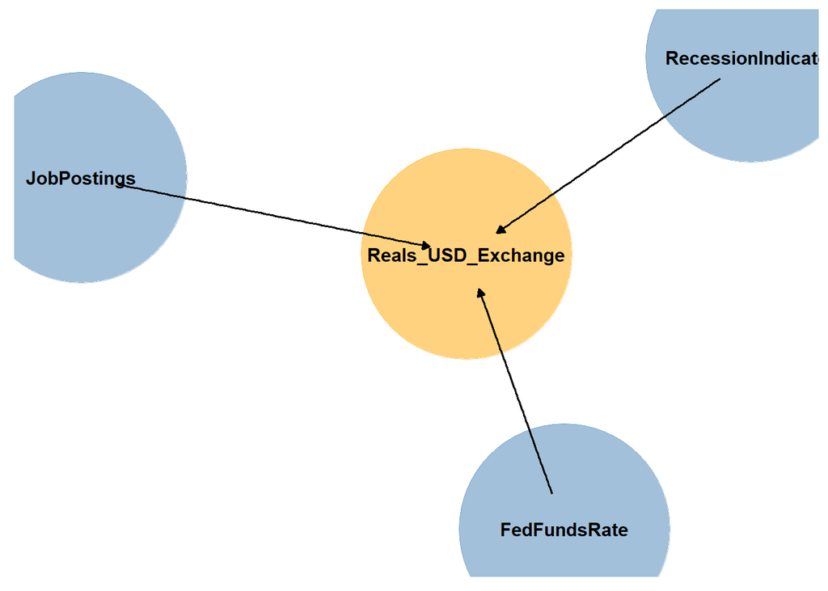

```r
causal_diagram <- dagitty("dag{
                          FedFundsRate -> Reals_USD_Exchange;
                          RecessionIndicator -> Reals_USD_Exchange;
                          JobPostings -> Reals_USD_Exchange }")
gg_dag(causal_diagram,
       size = 60,
       highlight = 'Reals_USD_Exchange')
```

## Causal Diagram Explanation

### Model Description

$$\text{Reals USD Exchange} \sim \text{Gamma distribution}(\mu_{[i]}, \sigma)$$

$$\beta_0\sim\text{Normal}(.76028,.65)$$

$$\beta_1\sim\text{Normal}(1.5, 2)$$

$$\beta_2\sim\text{Normal(.5, .5)}$$

$$\beta_3\sim\text{Normal(125, 30)}$$

$$\sigma\sim\text{exp}(0,3)$$

#### Rationale for Priors

Response Variable: Reals to USD Exchange Rate

Predictor Variable: US Federal Funds rate ($\beta_1$) https://www.grumpy-economist.com/p/do-higher-interest-rates-raise-the An increase to the Federal Funds Rate should create an initial boost in the value of the dollar. With a higher value assigned to the USD, the exchange rate should increase. Therefore, this should be a positive relationship.

Predictor Variable: US Job Postings According to the Federal Reserve Bank of New York, ($\beta_3$) “rise in employment strengthens the foreign exchange value of the dollar”. Therefore, also should be a positive relationship.

Categorical Variable: Brazil Recession Indicator ($\beta_{\text{RecessionIndicator[i]}}$) During a recession, the money that used to be able to purchase, say two gallons of milk, will now only be able to purchase a quarter gallon. This indicates that the currency has become less valueable and should therefore even out in relation to another currency, hence a negative relationship to the exchange rate.

## Prior Predictive Distribution

```r
n_sim <- 100
prior_pred_dist <- tibble(
  sim_id = c(1:n_sim)) |>
  mutate(
    b0 = rnorm(n_sim, mean = 0.76028, sd = 0.65),
    b1 = rnorm(n_sim, mean = 1.5, sd = 2),
    b2 = rnorm(n_sim, mean = 0.5, sd = 0.5),
    b3 = rnorm(n_sim, mean = 125, sd = 30),
    sigma = rexp(n_sim, rate = 3),
  ) |>
  rowwise()  |>
  mutate(
    mu = list(exp(b0 + b1 * exchange$FedFundsRate_scaled + b2 * exchange$RecessionIndicator + b3 * exchange$JobPostings_scaled))) |>
  unnest(cols = mu) |>
  ungroup() |>
  mutate(
    alpha = mu^2 / sigma^2,
    lambda = mu / sigma^2) |>
  rowwise() |>
  mutate(
    y_sim = rgamma(1, shape = alpha, rate = lambda)
  ) |>
  ungroup()
```

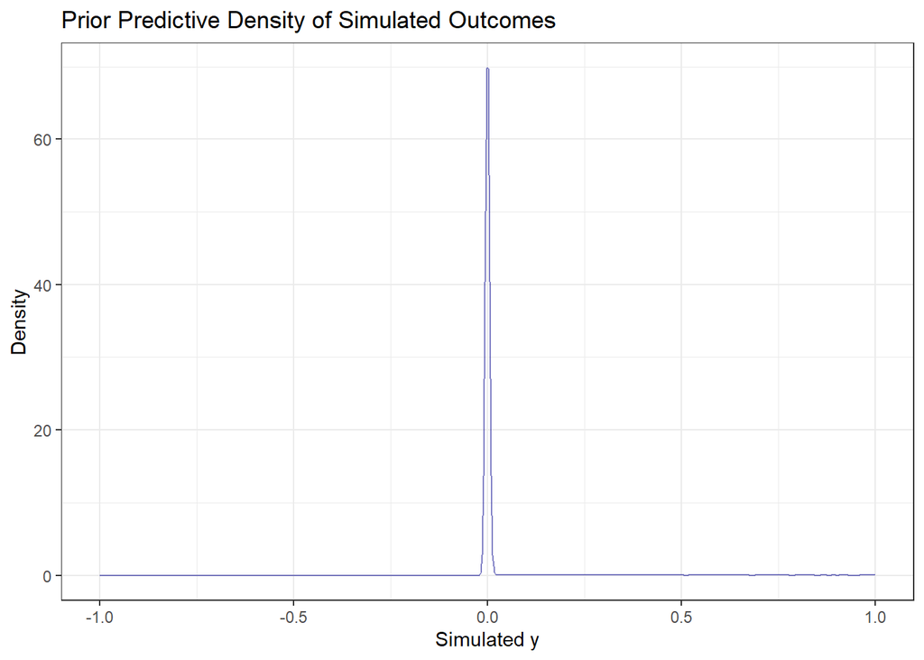

```r
gf_dens(~ y_sim, data = prior_pred_dist, color = "darkblue") |>
  gf_labs(
    title = "Prior Predictive Density of Simulated Outcomes",
    x = "Simulated y",
    y = "Density"
  ) +
  theme_bw() +
  xlim(-1, 1)
```

The prior predictive distribution is centered at zero, which suggests our priors are placing more weight on the lower tail of our distribution (meaning it is expecting an exchange rate close to zero). Alternatively, one or more of our priors could have been better-defined. We have learned that choosing GLM priors is difficult.

## Model Fitting

```r
exchange_fitted_model <- stan(file = 'finalproject.stan',
                              data = stan_exchange,
                              chains = 4,
                              iter = 3000,
                              warmup = 300,
                              refresh = 0)
```

```r
saveRDS(exchange_fitted_model, file="exchange_fitted_model.RDS")
```

```r
exchange_fitted_model <- readRDS("exchange_fitted_model.RDS")
```

## Chain Diagnostics

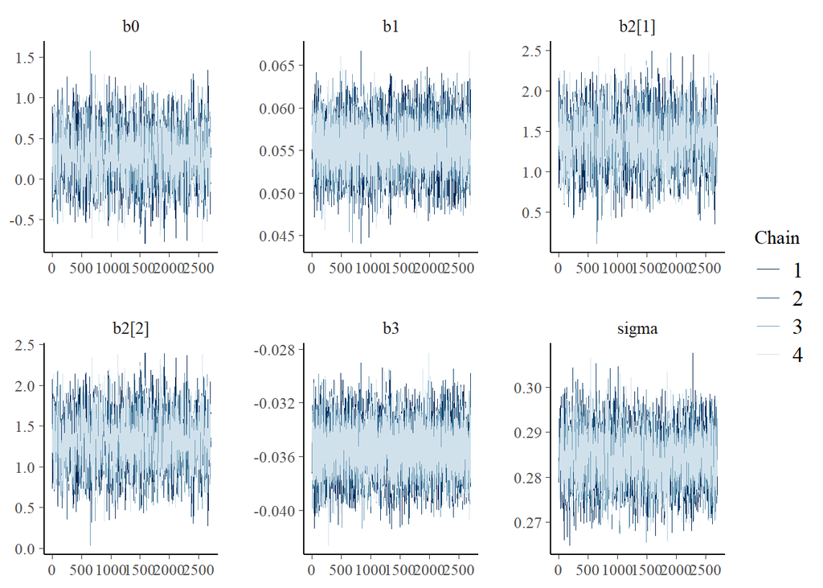

```r
mcmc_trace(exchange_fitted_model,
           pars = vars(starts_with("b"), "sigma"))
```

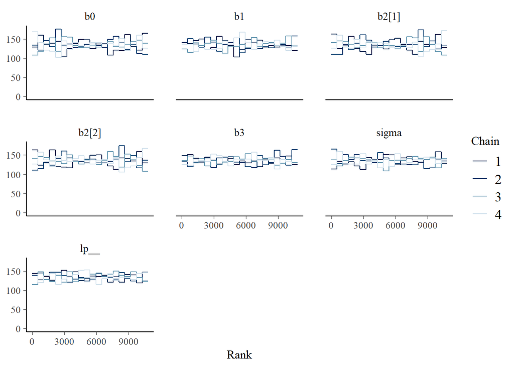

```r
mcmc_rank_overlay(exchange_fitted_model)
```

The chains of this trace rank plot are also stationary (they all mostly stay in the range of 100-150). The chains overlap, but are not directly on top of each other.

```r
exchange_fitted_model
```

```
Inference for Stan model: anon_model.
4 chains, each with iter=3000; warmup=300; thin=1;
post-warmup draws per chain=2700, total post-warmup draws=10800.

         mean se_mean   sd    2.5%     25%     50%     75%   97.5% n_eff Rhat
b0       0.30    0.01 0.32   -0.31    0.08    0.29    0.51    0.93  2241    1
b1       0.06    0.00 0.00    0.05    0.05    0.06    0.06    0.06  7397    1
b2[1]    1.40    0.01 0.32    0.77    1.19    1.40    1.62    2.01  2241    1
b2[2]    1.32    0.01 0.32    0.69    1.10    1.32    1.54    1.92  2242    1
b3      -0.04    0.00 0.00   -0.04   -0.04   -0.04   -0.03   -0.03  8641    1
sigma    0.28    0.00 0.01    0.27    0.28    0.28    0.29    0.30  3436    1
lp__  -218.11    0.03 1.75 -222.29 -219.05 -217.81 -216.82 -215.68  3238    1

Samples were drawn using NUTS(diag_e) at Tue Apr 29 13:56:24 2025.
For each parameter, n_eff is a crude measure of effective sample size,
and Rhat is the potential scale reduction factor on split chains (at
convergence, Rhat=1).
```

Our Rhat value is exactly 1, indicating that the model has converged and we used an appropriate number of post-warmup iterations. Our n_eff values are quite high, indicating that we have plenty of effective samples because we used a sufficient amount of warmup iterations.

## Posterior Predictive Distribution

```r
psamp <- as.data.frame(exchange_fitted_model)
glimpse(psamp)
```

```
Rows: 10,800
Columns: 7
$ b0      <dbl> 0.22393193, 0.23963192, 0.51826208, 0.82799831, 0.83703643, 0.…
$ b1      <dbl> 0.05571297, 0.05399135, 0.05588953, 0.05393180, 0.05429670, 0.…
$ `b2[1]` <dbl> 1.4778228, 1.4557592, 1.1796906, 0.8646105, 0.8580614, 0.85551…
$ `b2[2]` <dbl> 1.3947562, 1.3765594, 1.0984669, 0.7891505, 0.7765782, 0.78225…
$ b3      <dbl> -0.03434388, -0.03555921, -0.03733450, -0.03610573, -0.0361649…
$ sigma   <dbl> 0.2823628, 0.2859559, 0.2841962, 0.2827413, 0.2819081, 0.28197…
$ lp__    <dbl> -219.8004, -215.4440, -216.4111, -218.0782, -217.9426, -219.86…
```

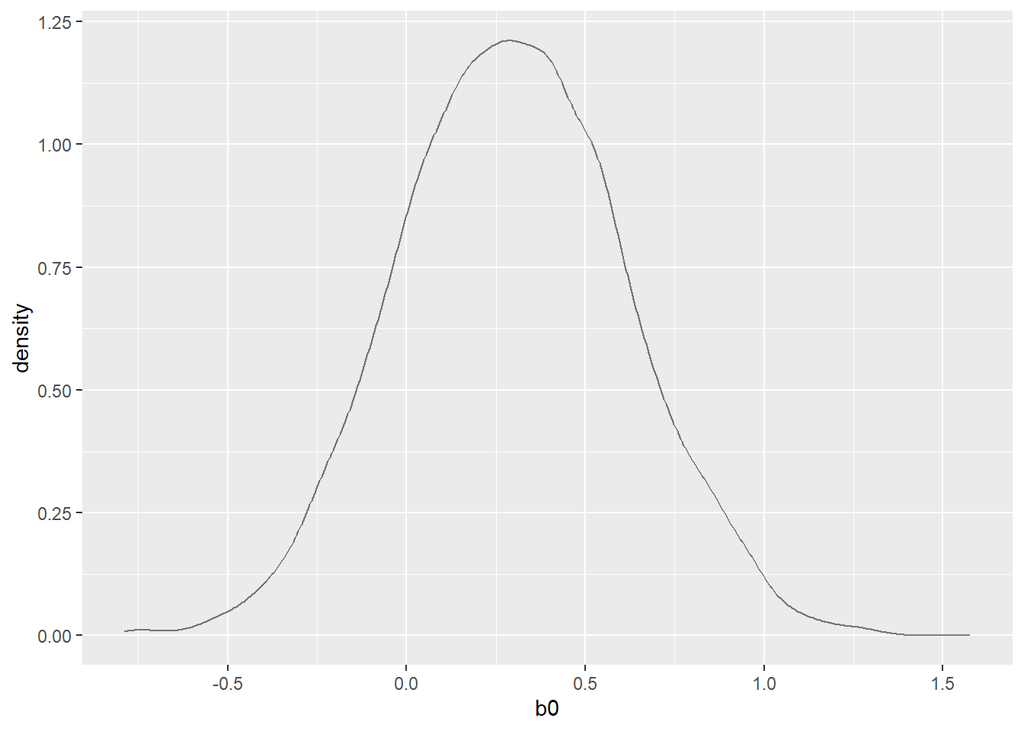

```r
gf_dens(~b0, data = psamp)
```

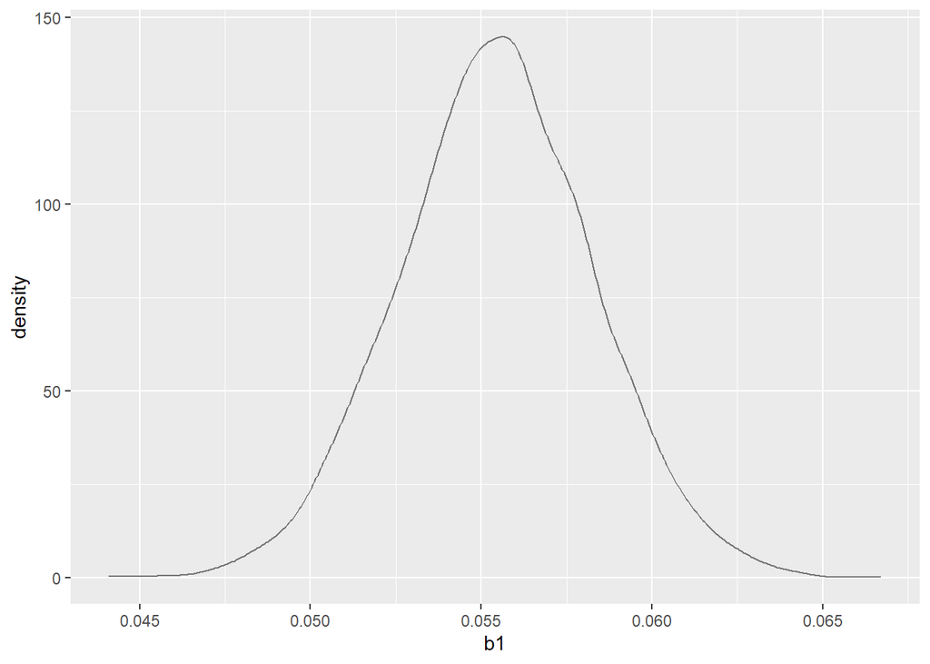

```r
gf_dens(~b1, data = psamp)
```

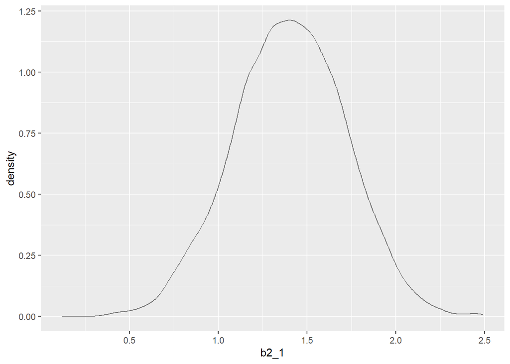

```r
psamp <- psamp |>
  rename(b2_1 = "b2[1]",
         b2_2 = "b2[2]")
gf_dens(~b2_1, data = psamp)
```

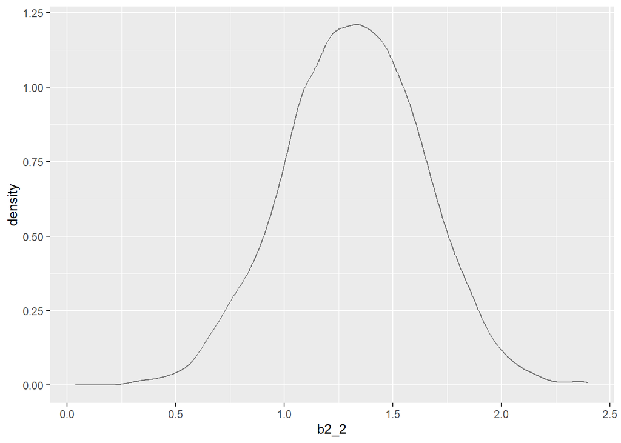

```r
gf_dens(~b2_2, data = psamp)
```

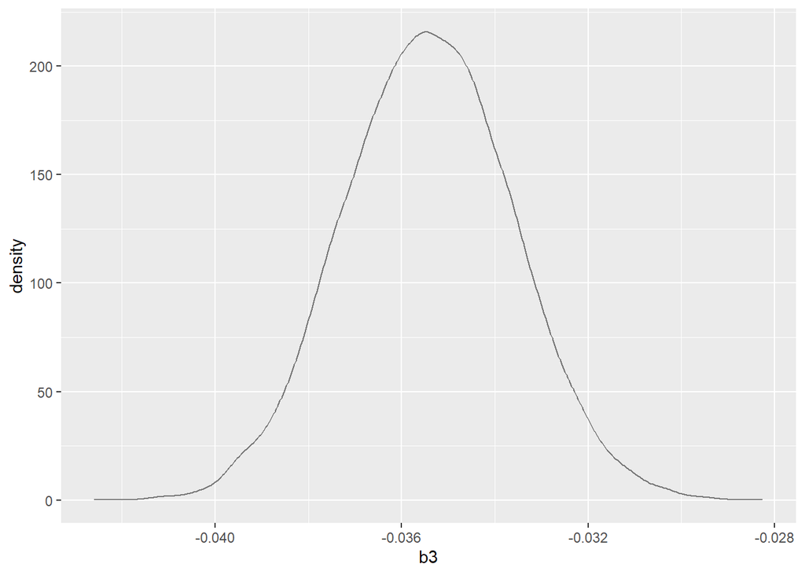

```r
gf_dens(~b3, data = psamp)
```

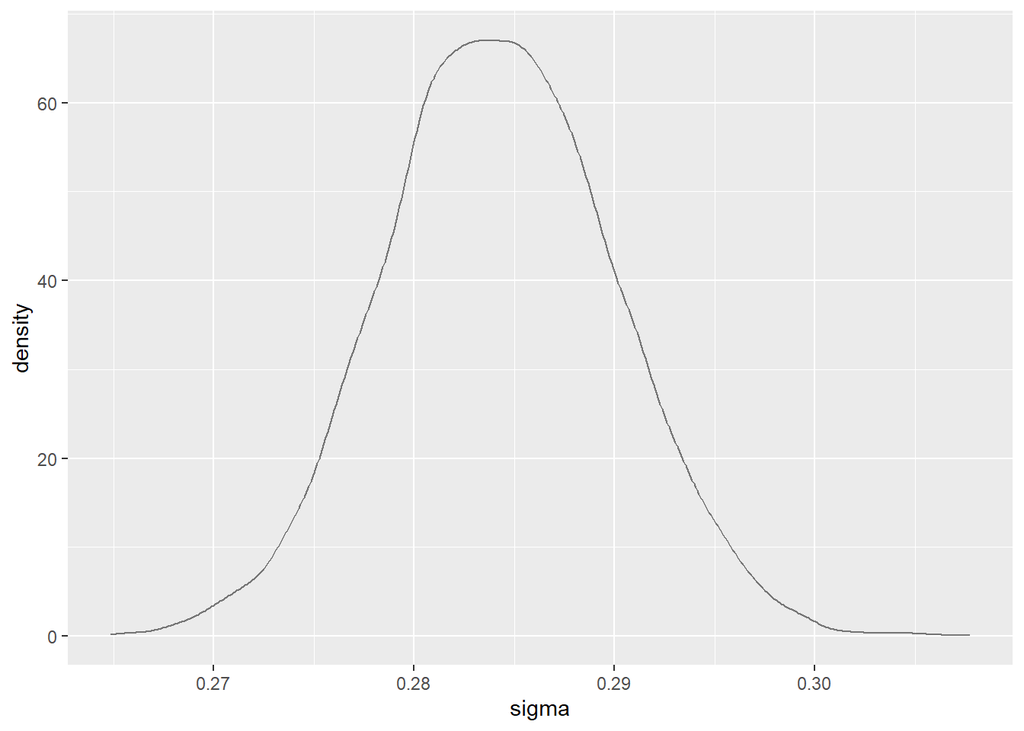

```r
gf_dens(~sigma, data = psamp)
```

```r
#rethinking::PSIS(exchange_fitted_model)
```

## Conclusions

Another factor to consider would be that there are two ways that an EXR can be changed. From each currency’s end, the impact on the EXR can be cancelled out or drastically magnified when there are changes to the economic conditions of both countries. Apart from the data that we gathered, we did not additionally consider single events such as political strife that may have created an anomaly in the EXR.

## Citations

Cochrane, J. H. (2024, September 16). Do higher interest rates raise the exchange rate? The Grumpy Economist. https://www.grumpy-economist.com/p/do-higher-interest-rates-raise-the

Harris, E., & Zabka, N. M. (1995). The employment report and the dollar. Number, 1. https://doi.org/10.2139/ssrn.1001251